# Simone Di Leo | Phd Student

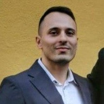

#### Simone Di Leo

Junior Research Fellow and Phd Student

## About Me

I am currently a Phd student in Management and Industrial engineering at Sapienza University of Rome with a focus on performance and data analysis.  
I work also in ETL, Data Analysis, Text Mining, Data visualization and infographics, etc...  
I don't think there's a position for the jobs I've done in the past...  
let's just say I do a little bit of everything in the data environment.

#### List of publications

I have made several conference contributions and academic publications.  
To see my google scholar profile with information about my publications click the button!

[Google Scholar](https://scholar.google.com/citations?user=uXEtOBsAAAAJ&hl=it)

[figure not shown]

## What I’m good at?

I have a lot of experience with programming (I have been programming for almost 10 years) and I have worked with various languages, from classic object-oriented to functional programming.  
Although I am an analytical, I have also worked a lot with graphics and design of both images and videos.

#### Data Analysis

Doing research, data analysis is my main activity. I'm specialized in statistical and performance analysis. The main methodologies I am familiar with are non-parametric and stochastic. In particular, I have experience with SFA and DEA analysis and, although to a lesser extent, MCDM as well. Lately I've been getting into ML (especially xgboost, svm and random forest) and text analysis(NRC sentiment dictionary and syuzhet analysis).

#### SQL, ETL and DB design

I've experience with classic SQL and the various CRUD operations.  
In addition, thanks to the last years of experience as a researcher, I often work in the ETL processes.  
Always in the context of data, I have experience in the design and implementation of databases from scratch.

#### Software Development

I've been developing since I was 16 in lots of languages.  
For the past few years I've been working primarily in C#/.NET and R.  
Most of my softwares are self-produced and are often in support of my research.

#### Data Visualization

Data visualization has become my greatest passion over time. I often create charts, infographics and interactive dashboards both numerical and geospatial.  
I have made my motto: "better an ugly chart than 10 tables".

## Demo Portfolio

In this section there are some of the demo projects I have worked on (or am working on).

all Data Viz Demo

[figure not shown]

#### MIUR Viz

[Link](https://simonedileo.github.io/MiurViz/)

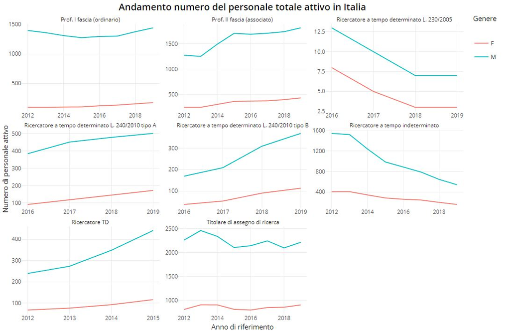

#### Open Data Demo

[Link](https://simonedileo.github.io/OpenDataMiur-Viz/)